# Exploring data

```r
library(lubridate)
```

# Terminology

“chat with client”

- episode = a transfer handover event (e.g. death, discharge, move within hospital)
- acute = sharp, sudden, short-term; opposite of chronic. Acute care includes hospitals, consultations and specialisms, emergency treatment, surgeries, diagnostic procedures. Whereas non-acute = long stay service, psychiatric services
- _qf = quality of data, qualifier to note about the value in the associated variable column
- Treat SIMD as one parameter to look at, also include other demographics

# Monthly a&e data

## Discharges —-

Explore discharges data

```r
discharges <- read_csv("data/a_and_e/opendata_monthly_ae_discharge_202305.csv") %>%
  clean_names()
```

```r
colnames(discharges)
```

```r
glimpse(discharges)
```

67,895 rows with 10 variables

### Looking at qf - quality notes

```r
discharges %>%
  filter(!is.na(discharge_qf)) %>%
  distinct(discharge)
```

All the _qf notes for discharge indicate a NA in discharge

```r
discharges %>%
  summarise(across(.cols = everything(),
                   .fns = ~sum(is.na(.x))))
```

67,895 rows 9,525 have NA in discharge 7,748 NA in age

Data file has

- month
- country?
- hbt = health board code, lookup here: https://www.opendata.nhs.scot/dataset/geography-codes-and-labels/resource/652ff726-e676-4a20-abda-435b98dd7bdc
- treatment_location - is this hospital?
- department_type - look at all for all A&E, but not there are departments
- age group (e.g. 18-24)
- discharge = type of discharge event (e.g. “Discharge Home…”, “Transferred”, “Admission…”)
- number of attendances = frequency

```r
head(discharges)
```

### Plot discharges by age

```r
discharges %>%
  mutate(age = factor(age, levels = c("Under 18", "18-24", "25-39", "40-64", "65-74", "75 plus", NA_character_))) %>%
  ggplot() +
  aes(y = discharge, x = number_of_attendances, fill = age) +
  geom_col()
```

```r
min(discharges$month)
max(discharges$month)
```

Date range: 2018-01 to 2023-05

```r
unique(discharges$department_type)
```

## Attendances, demographics —-

```r
demographics <- read_csv("data/a_and_e/opendata_monthly_ae_demographics_202305.csv") %>%
  clean_names()
```

```r
glimpse(demographics)
```

```
Rows: 87,945
Columns: 11
$ month                 <dbl> 201801, 201801, 201801, 201801, 201801, 201801, 201801, 2018…
$ country               <chr> "S92000003", "S92000003", "S92000003", "S92000003", "S920000…
$ hbt                   <chr> "S08000015", "S08000015", "S08000015", "S08000015", "S080000…
$ department_type       <chr> "Emergency Department", "Emergency Department", "Emergency D…
$ age                   <chr> "18-24", "18-24", "18-24", "18-24", "18-24", "18-24", "18-24…
$ age_qf                <chr> NA, NA, NA, NA, NA, NA, NA, NA, NA, NA, NA, NA, NA, NA, NA, …
$ sex                   <chr> "Female", "Female", "Female", "Female", "Female", "Female", …
$ sex_qf                <chr> NA, NA, NA, NA, NA, NA, NA, NA, NA, NA, NA, NA, NA, NA, NA, …
$ deprivation           <dbl> 1, 2, 3, 4, 5, NA, 1, 2, 3, 4, 5, NA, 1, 2, 3, 4, 5, NA, 1, …
$ deprivation_qf        <chr> NA, NA, NA, NA, NA, ":", NA, NA, NA, NA, NA, ":", NA, NA, NA…
$ number_of_attendances <dbl> 155, 112, 50, 39, 27, 4, 170, 96, 44, 38, 40, 1, 324, 186, 9…
```

This gives demographics of overall attendances but we can’t look at waiting times x demographics

### monthly A&E atts by hbt

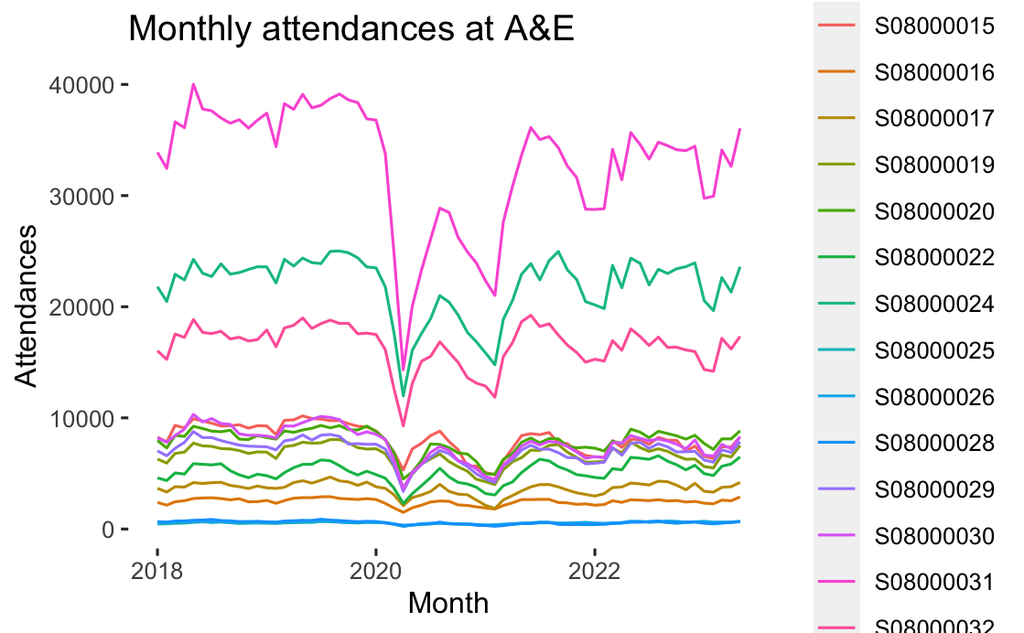

```r
demographics %>%
  group_by(month, hbt) %>%
  summarise(total_attendances = sum(number_of_attendances)) %>%
  mutate(month = ym(month)) %>%
  ggplot() +
  geom_line(aes(x = month, y = total_attendances, colour = hbt)) +
  labs(x = "Month", y = "Attendances", colour = "Health board",
       title = "Monthly attendances at A&E") +
  theme(panel.background = element_blank())
```

```r
ggsave("monthly_attendances_A&E_hb.png")
```

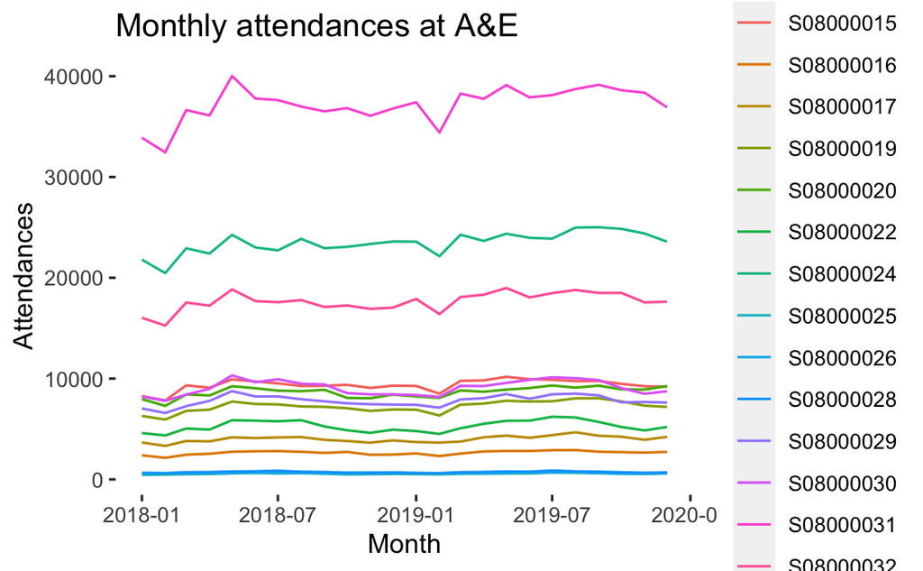

```r
demographics %>%
  group_by(month, hbt) %>%
  summarise(total_attendances = sum(number_of_attendances)) %>%
  mutate(month = ym(month)) %>%
  filter(month < "2020-01-01") %>%
  ggplot() +
  geom_line(aes(x = month, y = total_attendances, colour = hbt)) +
  labs(x = "Month", y = "Attendances", colour = "Health board",
       title = "Monthly attendances at A&E") +
  theme(panel.background = element_blank())
```

```r
ggsave("monthly_attendances_A&E_hb_before2020.png")
```

### monthly A&E atts by depriv

```r
class(demographics$deprivation)
```

```
[1] "numeric"
```

[figure not shown]

```r
demographics %>%
  group_by(month, deprivation) %>%
  summarise(total_attendances = sum(number_of_attendances),
            total_attendances_mil = total_attendances/1000000,
            deprivation = as.character(deprivation)) %>%
  ggplot() +
  geom_col(aes(x = ym(month), y = total_attendances, fill = deprivation),
           position = "stack") +
  scale_fill_brewer(palette = "Set1") +
  scale_y_continuous(labels = scales::comma) +
  labs(x = "Month", y = "Attendances", fill = "Deprivation quintile",
       title = "Monthly attendances at A&E") +
  theme(panel.background = element_blank())
```

### atts filter options

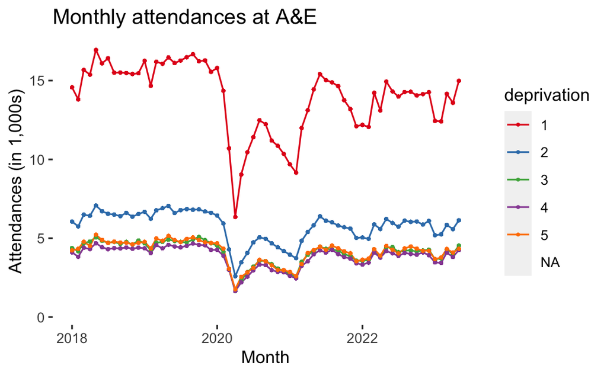

```r
demographics %>%
  filter(hbt == "S08000031") %>%
  group_by(month, deprivation) %>%
  summarise(total_attendances = sum(number_of_attendances),
            total_attendances_thous = total_attendances/1000,
            deprivation = as.character(deprivation)) %>%
  ggplot() +
  aes(x = ym(month), y = total_attendances_thous,
               colour = deprivation) +
  geom_line() +
  geom_point(size = 0.5) +
  scale_colour_brewer(palette = "Set1") +
  scale_y_continuous(labels = scales::comma) +
  labs(x = "Month", y = "Attendances (in 1,000s)", fill = "Deprivation quintile",
       title = "Monthly attendances at A&E") +
  theme(panel.background = element_blank())
```

## Referral —-

```r
referral <- read_csv("data/a_and_e/opendata_monthly_ae_referral_202305.csv")
```

```r
glimpse(referral)
```

Referral gives how they were referred into the A&E (frequency of method)

## When —-

```r
when <- read_csv("data/a_and_e/opendata_monthly_ae_when_202305.csv")
```

```r
glimpse(when)
```

the …*when*… data file gives the number of attendances by time of day (1h buckets, e.g. 08:00 to 08:59)

# Try mapping HBs —

(For Ali)

```r
library(sf)
```

```r
hb_geo <- st_read(dsn = "data/map/healthboard_geo/",
                  layer = "SG_NHS_HealthBoards_2019")
```

```r
plot(hb_geo)
```

# Inpatient and day cases

## inpatient by age and sex

```r
inpatient_age_and_sex <- read_csv("data/inpatient_and_daycase_by_nhs_board_of_treatment_age_and_sex.csv")
```

```r
glimpse(inpatient_age_and_sex)
```

```
Rows: 128,811
Columns: 18
$ Quarter                  <chr> "2017Q4", "2018Q1", "2018Q2", "2018Q3", "2018Q4", "2019Q1…
$ QuarterQF                <chr> NA, NA, NA, NA, NA, NA, NA, NA, NA, NA, NA, NA, NA, NA, N…
$ HB                       <chr> "S08000015", "S08000015", "S08000015", "S08000015", "S080…
$ HBQF                     <chr> NA, NA, NA, NA, NA, NA, NA, NA, NA, NA, NA, NA, NA, NA, N…
$ Location                 <chr> "S08000015", "S08000015", "S08000015", "S08000015", "S080…
$ LocationQF               <chr> "d", "d", "d", "d", "d", "d", "d", "d", "d", "d", "d", "d…
$ AdmissionType            <chr> "Elective Inpatients", "Elective Inpatients", "Elective I…
$ AdmissionTypeQF          <chr> NA, NA, NA, NA, NA, NA, NA, NA, NA, NA, NA, NA, NA, NA, N…
$ Sex                      <chr> "Female", "Female", "Female", "Female", "Female", "Female…
$ Age                      <chr> "0-9 years", "0-9 years", "0-9 years", "0-9 years", "0-9 …
$ Episodes                 <dbl> 10, 10, 17, 10, 5, 10, 13, 10, 10, 10, 5, 0, 5, 5, 0, 5, …
$ LengthOfEpisode          <dbl> 18, 13, 18, 6, 9, 10, 18, 11, 10, 15, 5, 0, 10, 7, 5, 5, …
$ AverageLengthOfEpisode   <dbl> 1.8000000, 1.3000000, 1.0588235, 0.6000000, 1.8000000, 1.…
$ AverageLengthOfEpisodeQF <chr> NA, NA, NA, NA, NA, NA, NA, NA, NA, NA, NA, "z", NA, NA, …
$ Stays                    <dbl> 25, 19, 28, 19, 18, 24, 30, 30, 22, 19, 5, 0, 10, 5, 0, 5…
$ LengthOfStay             <dbl> 33, 27, 35, 21, 22, 30, 37, 38, 27, 26, 5, 0, 17, 7, 5, 8…
$ AverageLengthOfStay      <dbl> 1.3200000, 1.4210526, 1.2500000, 1.1052632, 1.2222222, 1.…
$ AverageLengthOfStayQF    <chr> NA, NA, NA, NA, NA, NA, NA, NA, NA, NA, NA, "z", NA, NA, …
```

Key measures:

- Length of episode
- Length of stay
- Demographics: age, sex
- Location
- Year quarter

```r
# admission types
inpatient_age_and_sex %>%
  group_by(AdmissionType) %>%
  summarise(count = n())
```

| AdmissionType | count |
| --- | --- |
| All Day cases | 20429 |
| All Inpatients | 20859 |
| All Inpatients and Day cases | 21184 |
| Elective Inpatients | 18327 |
| Emergency Inpatients | 19627 |
| Not Specified | 9854 |
| Transfers | 18531 |

Not sure which are acute?

```r
inpatient_age_and_sex %>%
  group_by(Quarter) %>%
  summarise(count = n())
```

2017Q4 to 2020Q1

## inpatient …

[output not shown]

[output cut: 990 more lines]

# Covid

## Hospital admissions during covid by age, sex

```r
covid_age_sex <- read_csv("data/covid/hospital_admissions/hospital_admissions_hb_agesex_20230706.csv")
```

```r
glimpse(covid_age_sex)
```

```
Rows: 74,164
Columns: 12
$ WeekEnding       <dbl> 20200105, 20200105, 20200105, 20200105, 20200105, 20200105, 20200…
$ HB               <chr> "S08000015", "S08000015", "S08000015", "S08000015", "S08000015", …
$ HBQF             <chr> NA, NA, NA, NA, NA, NA, NA, NA, NA, NA, NA, NA, NA, NA, NA, NA, N…
$ AgeGroup         <chr> "Under 5", "5 - 14", "15 - 44", "45 - 64", "65 - 74", "75 - 84", …
$ AgeGroupQF       <chr> NA, NA, NA, NA, NA, NA, NA, "d", "d", "d", NA, NA, NA, NA, NA, NA…
$ Sex              <chr> "All", "All", "All", "All", "All", "All", "All", "All", "Female",…
$ SexQF            <chr> "d", "d", "d", "d", "d", "d", "d", "d", NA, NA, "d", "d", "d", "d…
$ AdmissionType    <chr> "All", "All", "All", "All", "All", "All", "All", "All", "All", "A…
$ AdmissionTypeQF  <chr> "d", "d", "d", "d", "d", "d", "d", "d", "d", "d", "d", "d", "d", …
$ NumberAdmissions <dbl> 89, 26, 170, 247, 184, 169, 106, 991, 500, 483, 25, 27, 44, 59, 6…
$ Average20182019  <dbl> 93.0, 33.0, 191.5, 260.5, 196.5, 179.5, 128.0, 1082.0, 559.5, 513…
$ PercentVariation <dbl> -4.3, -21.2, -11.2, -5.2, -6.4, -5.8, -17.2, -8.4, -10.6, -5.8, -…
```

- Time: week ending
- HB (but not location)
- age group, sex
- admission type and number
  - average 20182019 ascomparator
  - % variation

```r
covid_age_sex %>%
  summarise(count = n(), .by = AdmissionType)
```

| AdmissionType | count |
| --- | --- |
| All | 27141 |
| Emergency | 26166 |
| Planned | 20857 |

```r
min(covid_age_sex$WeekEnding)
max(covid_age_sex$WeekEnding)
```

5th Jan 2020 to 25 June 2023 with a comparator to same week in 2018/2019 (average of the two years)

Can look at emergency admissions and see % variation from 2018/2019 average

## hosp admissins by specialty?

[output not shown]

[output cut: 990 more lines]

# Treatment wait times

```r
performance_completed_treatment_waits <- read_csv("data/treatment_waiting_times/sot_performance_completed_waits_mar23.csv") %>%
  clean_names()
```

```r
performance_completed_treatment_waits %>%
  summarise(count = n(), .by = patient_type)
```

| patient_type | count |
| --- | --- |
| New Outpatient | 21140 |
| Inpatient/Day case | 14455 |

```r
performance_completed_treatment_waits %>%
  summarise(count = n(), .by = specialty)
```

| specialty | count |
| --- | --- |
| Z9 | 1344 |
| A1 | 1075 |
| A11 | 111 |
| A2 | 1085 |
| A21 | 29 |
| A3 | 276 |
| A6 | 465 |
| A7 | 890 |
| A8 | 538 |
| A81 | 497 |

[output cut: 80 more lines]

[output not shown]

| month_ending | hbt | hbtqf | patient_type | specialty | specialty_qf | number_of_waits | number_of_waits_qf | over12weeks | over12weeks_qf | median | median_qf | x90th_percentile | x90th_percentile_qf | specialty_name |
| --- | --- | --- | --- | --- | --- | --- | --- | --- | --- | --- | --- | --- | --- | --- |
| 20130630 | S92000003 | d | New Outpatient | Z9 | d | 344388 | NA | 20969 | NA | 39.0 | NA | 83.0 | NA | All specialties, topic specific |
| 20140630 | S92000003 | d | New Outpatient | Z9 | d | 363867 | NA | 25823 | NA | 42.0 | NA | 83.0 | NA | All specialties, topic specific |
| 20150630 | S92000003 | d | New Outpatient | Z9 | d | 357129 | NA | 41651 | NA | 42.0 | NA | 90.0 | NA | All specialties, topic specific |
| 20160630 | S92000003 | d | New Outpatient | Z9 | d | 361398 | NA | 44361 | NA | 41.0 | NA | 93.0 | NA | All specialties, topic specific |
| 20170630 | S92000003 | d | New Outpatient | Z9 | d | NA | : | NA | : | NA | : | NA | : | All specialties, topic specific |
| 20180630 | S92000003 | d | New Outpatient | Z9 | d | NA | : | NA | : | NA | : | NA | : | All specialties, topic specific |
| 20190630 | S92000003 | d | New Outpatient | Z9 | d | 362025 | NA | 77289 | NA | 41.0 | NA | 146.0 | NA | All specialties, topic specific |
| 20200630 | S92000003 | d | New Outpatient | Z9 | d | 129957 | NA | 31350 | NA | 18.0 | NA | 141.0 | NA | All specialties, topic specific |
| 20210630 | S92000003 | d | New Outpatient | Z9 | d | 283017 | NA | 76715 | NA | 33.0 | NA | 250.0 | NA | All specialties, topic specific |
| 20220630 | S92000003 | d | New Outpatient | Z9 | d | 298621 | NA | 90678 | NA | 39.0 | NA | 253.0 | NA | All specialties, topic specific |

[output cut: 990 more lines]

### which specialties are acute?

https://publichealthscotland.scot/publications/acute-hospital-activity-and-nhs-beds-information-quarterly/acute-hospital-activity-and-nhs-beds-information-quarterly-quarter-ending-30-june-2021/glossary/

“Excludes obstetric services; psychiatric services; long stay care services; and non-consultant led clinics.”

[output not shown]

[output cut: 990 more lines]

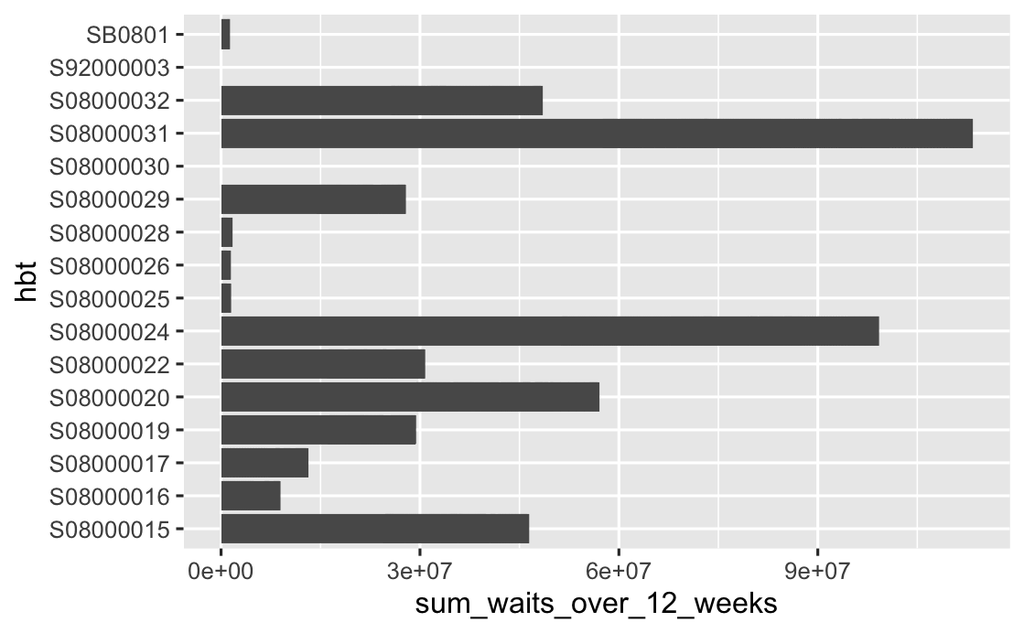

```r
# sum of waits over 12 weeks for each specialty
performance_completed_treatment_waits %>%
  group_by(hbt, specialty_name) %>%
  summarise(sum_waits_over_12_weeks = sum(over12weeks),
            prop_waits_over_12_weeks = sum_waits_over_12_weeks / number_of_waits) %>%
  ggplot() +
  geom_col(aes(x = sum_waits_over_12_weeks, y = hbt))
```

### time

filter for speciality look over time

```r
performance_completed_treatment_waits %>%
  summarise(sum)
```

[output not shown]

[output cut: 990 more lines]